# Homework 3 Solutions

# Ch. 3, Coding Question 2

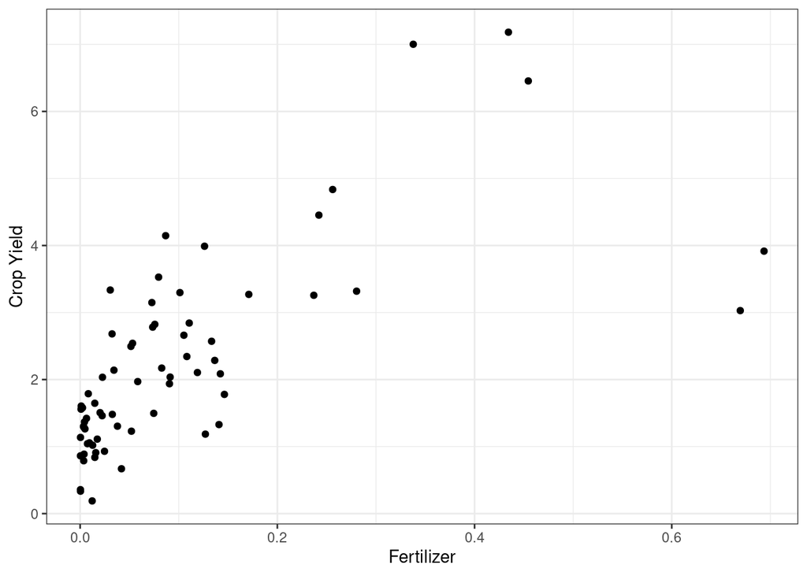

```r
# load data
load("../../Detailed Course Notes/data/fertilizer_2000.RData")

# load packages
library(ggplot2)

# make scatter plot
ggplot(data=fertilizer_2000,
       mapping=aes(x=avfert, y=avyield)) +
  geom_point() +
  ylab("Crop Yield") +
  xlab("Fertilizer") +
  theme_bw()
```

It seems like countries with higher fertilizer usage tend to have higher crop yields.

# Ch. 3, Coding Question 3

```r
# load data
library(Ecdat)
data("Airq", package="Ecdat")

# a) estimate mean rainfall
ybar <- mean(Airq$rain)
ybar
```

```
## [1] 36.078
```

```r
# b) standard error
V <- var(Airq$rain)
n <- nrow(Airq)
se <- sqrt(V)/sqrt(n)
se
```

```
## [1] 2.462628
```

```r
# c) t-statistic
h0 <- 25
t <- (ybar-h0)/se
t
```

```
## [1] 4.498446
```

Since $|t| > 1.96$, we would reject $H_0$ at the 5% significance level.

```r
# d) p-value
pval <- 2*pnorm(-abs(t))
pval
```

```
## [1] 6.845183e-06
```

There is virtually a 0 percent chance of getting a t-statistic this large in absolute value if the null hypotheses were true.

```r
# e) confidence interval
ciL <- ybar - 1.96*se
ciU <- ybar + 1.96*se
paste0("[",round(ciL,3),", ", round(ciU,3), "]")
```

```
## [1] "[31.251, 40.905]"
```

```r
# f) summary statistics
library(modelsummary)
datasummary_balance(~coas, Airq)
```

|  | no (N=9) Mean | no (N=9) Std. Dev. | yes (N=21) Mean | yes (N=21) Std. Dev. | Diff. in Means | Std. Error |
| --- | --- | --- | --- | --- | --- | --- |
| airq | 125.3 | 10.5 | 95.9 | 28.7 | −29.5 | 7.2 |
| vala | 4118.2 | 5909.8 | 4218.6 | 4136.7 | 100.4 | 2166.9 |
| rain | 32.3 | 7.6 | 37.7 | 15.2 | 5.4 | 4.2 |
| dens | 1706.4 | 3014.6 | 1738.1 | 2821.2 | 31.7 | 1178.5 |
| medi | 6290.3 | 10065.4 | 10842.2 | 13396.8 | 4551.9 | 4450.1 |

# Ch. 3, Extra Question 5

Consistency is a large sample property for an estimator. It says that, if we *have a large sample*, then our estimator should be close to the population quantity that we are trying to estimate.

An unbiased estimator is one that, if we could repeatedly draw samples of size $n$ ($n$ could be large or small here) and re-estimate the parameter of interest, then on average (*across samples*), we our estimate would be equal to the population parameter that we are trying to estimate.

# Ch. 3, Extra Question 6

No, an unbiased estimator does not necessarily have to be consistent. Consider estimating $\mathbb{E}[Y]$ by $Y_1$ (i.e., using the value of $Y$ for the first observation in the data). This estimate of $\mathbb{E}[Y]$ is unbiased (since $\mathbb{E}[Y_1] = \mathbb{E}[Y])$, but it is not consistent (because it does not even depend on the sample size at all).

# Ch. 3, Extra Question 7

No, consistent estimators can be biased. Consider estimating $\mathbb{E}[Y]$ by $\bar{Y} + \frac{c}{n}$ where $c$ is a constant. This is consistent because $\bar{Y} \rightarrow \mathbb{E}[Y]$ as $n \rightarrow \infty$ (by the law of large numbers) and $\frac{c}{n} \rightarrow 0$ as $n \rightarrow \infty$ (because it is a constant divided by a number that is going to infinity). However, notice that

$$\begin{aligned}
\mathbb{E}\left[\bar{Y} + \frac{c}{n} \right] &= \mathbb{E}[Y] + \frac{c}{n} \\
& \neq \mathbb{E}[Y]
\end{aligned}$$
so, for any fixed sample size $n$, $\bar{Y} + \frac{c}{n}$ is biased for $\mathbb{E}[Y]$.

# Ch. 3, Extra Question 8

1. Since $n$ grows faster than $\sqrt{n}$, $n \left(\frac{1}{n}\sum_{i=1}^n (Y_i - \mathbb{E}[Y])\right)$ diverges (i.e., the absolute value goes to infinity as $n \rightarrow \infty$)
2. Since $n^{1/3}$ grows slower than $\sqrt{n}$, $n^{1/3} \left(\frac{1}{n}\sum_{i=1}^n (Y_i - \mathbb{E}[Y])\right)$ converges to 0 as $n \rightarrow \infty$